# Emoji prediction

Tijs Van den Heuvel

10/15/2020

# Tweet analysis and emoji prediction

The goal of this project is to predict an emoji based on text.

When looking for similar projects, they get to an accuracy of 33%, this will be the succes criteria

It would be great if an algorithm could suggest some emojis based on a different piece of text.

The data set consists of a collection of tweets with at least one emoji.

[data source](https://www.kaggle.com/rexhaif/emojifydata-en)

The data is gathered, selected and reformatted by *Daniil Larionov* from the *ArchiveTeam Twitter data* source

I transformed this data into a data table with the use of PySpark and regex in this jupyter notebook:

preprocess

- I spend a lot of time making this fast enough for large data sets
- I did some initial experimentation and data cleaning with a 10 tweets set
- Then I created R code to construct a model with a 165 tweets set
- When that model worked (with an accuracy of 18%) I proceeded to fix the pre-processor to convert the entire data set

## load data

### mini set

```r
tweetDT <- fread("./data/165tweets.csv")
```

### dev set (1.3 mil)

```r
tweetDT <- fread("./data/dev.csv")
```

### Full set

- already split into training and test set
- unpractical for cleansing and one hot encoding of output

```r
trainDT <- fread("./data/train.csv")
testDT <- fread("./data/test.csv")
tweetDT=rbind(trainDT,testDT)
```

## a sample of the input data

```r
tweetDT[sample(1:.N,5)]
```

| text | emoji |
| --- | --- |
| Now gon say which â\200œ rule â\200œ and give us these ðŸ\217½ â\200\215 ï¸\217 ofcourse we failed ALL OF THESE | face_with_tears_of_joy |
| We are listening amp BTS ARMY is Feeling the love ï¸\217 Thank YOU for playing MicDrop Remix | red_heart |
| Over 2 million views | OK_hand |
| Thank you Usha ï¸\217 | red_heart |
| ï¸\217 ï¸\217 Small Play Like This | rolling_on_the_floor_laughing |

## Clean the tweet text

- remove all non ascii characters
- remove numbers
- merge multiple spaces
- remove trailing spaces
- to lower case
- remove empty tweets (tweets that were only non ascii and numbers)

> some of these steps could remove too much information, can be revised

```r
tweetDT$text<-gsub('[^\x01-\x7F]',' ',tweetDT$text)
tweetDT$text<-gsub('[0-9]+',' ',tweetDT$text)
tweetDT$text<-gsub('\\s+',' ',tweetDT$text)
tweetDT$text<-gsub(' $','',tweetDT$text)
tweetDT$text<-tolower(tweetDT$text)
tweetDT<- tweetDT[tweetDT$text!='',]
```

## a sample of the cleaned tweets

```r
tweetDT[sample(1:.N,5)]
```

| text | emoji |
| --- | --- |
| parkland high school student media politicizing tragedy to push gun control not focusing on students | police_car_light |
| miss these s boyband icons | smiling_face_with_heart-eyes |
| im lying to you the only spirit i drink ke gin im a beer guy | face_with_tears_of_joy |
| also getting snipped isnt going to solve a hygene problem it sounds like she just prefers a snipped man say it with your chest | rolling_on_the_floor_laughing |
| wanna make some nice seafood weitsi | smiling_face_with_smiling_eyes |

## inspect tweet size

```r
tweetDT$text %>% strsplit(" ") %>% sapply(length) %>% summary()
```

```
   Min. 1st Qu.  Median    Mean 3rd Qu.    Max.
   1.00    6.00   10.00   10.84   15.00   55.00
```

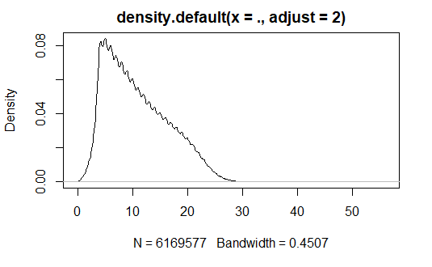

```r
tweetDT$text %>% strsplit(" ") %>% sapply(length) %>% density(adjust = 2) %>%plot()
```

### total vocabulary size

```r
tweetDT$text %>% strsplit(" ") %>% as.list() %>% unlist() %>% unique() %>%length()
```

```
[1] 232574
```

### emoji count

this will be the size of the output layer of the network

```r
emoji_count <- unique(tweetDT$emoji)%>%length()
emoji_count
```

```
[1] 49
```

## Text classification with Tensorflow

I started from this tensorflow [tutorial](https://tensorflow.rstudio.com/tutorials/beginners/basic-ml/tutorial_basic_text_classification/)

- the input is the text of the tweet
- the output is the emoji
- a neural network takes in tensors and not text so I needed to prepare the data

```r
library(keras)
library(dplyr)
library(ggplot2)
library(purrr)
```

### prepare the input data

- create a dictionary & represent each of the 10,000 most common words by an integer
- one hot encoding would create a 10,000D vector but that’s too expensive
- Tokenization is also a method for encoding words with a vocabulary index based on word frequency
- text vectorization:
  - pad the arrays so they all have same length
  - create integer tensor of shape `num_words * max_length`
  - use an embedding layer capable of handling this shape as first layer
- `adapt` the text vectorization layer to learn about the data set vocabulary

```r
num_words <- 10000
max_length <- 32
text_vectorization <- layer_text_vectorization(
  max_tokens = num_words,
  output_sequence_length = max_length,
)
```

[output not shown]

```r
text_vectorization %>% adapt(tweetDT$text)
```

```
2020-11-23 16:07:30.492535: W tensorflow/core/framework/cpu_allocator_impl.cc:81] Allocation of 1065116944 exceeds 10% of free system memory.
2020-11-23 16:07:30.494813: W tensorflow/core/framework/cpu_allocator_impl.cc:81] Allocation of 1597675416 exceeds 10% of free system memory.
```

#### text vectorization insight

vocabulary sample

```r
get_vocabulary(text_vectorization)%>%sample(10)
```

[output not shown]

how text vectorization layer transforms input

```r
text_vectorization(matrix(tweetDT$text[1], ncol = 1))
```

[output not shown]

### prepare the output data

- the emojis have to be encoded as a vector
- one hot is a decent method size there are 49 different emojis
- keras had built in function: to_categorical but it needs integer input
- convert labels to integers
- first column is entirely empty so I remove it
- create an emoji dictionary to find which number maps to which emoji after prediction

```r
emoji_int <- match(tweetDT$emoji,unique(tweetDT$emoji))

one_hot_emoji <- to_categorical(emoji_int)
one_hot_emoji <- one_hot_emoji[,2:(emoji_count+1)]

emoji_dict <- tweetDT$emoji%>%unique()
```

### split the dataset into training & testing

- 80% training, 20% testing
- division arbitrarily chosen

```r
training_id <- sample.int(nrow(tweetDT), size = nrow(tweetDT)*0.8)
training <- tweetDT[training_id,]
testing <- tweetDT[-training_id,]
oh_train <-one_hot_emoji[training_id,]
oh_test <- one_hot_emoji[-training_id,]

nrow(training)
```

```
[1] 4935661
```

```r
nrow(testing)
```

```
[1] 1233916
```

### design the model

- how many layers?
- how many hidden units?
- what types of building blocks?
- what type of architecture?

#### model 1 FFA

- I started from the model from the tutorial
- I added an extra dense layer of size 16
- I tried bigger layers of size 32 and 50
- I tried more layers, up to 5
- I removed most of the dropout because that made the accuracy increase
- I didn’t realize that this was just overfitting
- Then I added more dropout after each layer and had an accuracy of 38%
- Then I realized I had duplicate rows because some tweets had multiples of the same emoji
- This caused the problem that the same record was in the training and test set
- When removing the duplicates, the accuracy dropped to 23%

initial FFA from tutorial:

```r
input <- layer_input(shape = c(1), dtype = "string")

output <- input %>%
  text_vectorization() %>%
  layer_embedding(input_dim = num_words + 1, output_dim = 16) %>%
  layer_global_average_pooling_1d() %>%
  layer_dense(units = 16, activation = "relu") %>%
  layer_dropout(0.5) %>%
  layer_dense(units = emoji_count, activation = "softmax")

model <- keras_model(input, output)
```

How many layers ? 1

tested with 50 unit layers

- 1 dense layer: 24.6% (19 epochs)
- 2 dense layers: 24.0%
- 3 dense layers: 23%
- 4 dense layers: 22%

how many units per layer?

- 40,50 units: 24.36%
- 40,45 units: 24.5%
- 50,50 units: 24.6%
- 55,50 units: 24.45%
- 55,55 units: 24.58%
- 60,55 units: 24.60%
- 70,60 units: 24.68%
- 80,70 units: 24.56%

```r
input <- layer_input(shape = c(1), dtype = "string")

output <- input %>%
  text_vectorization() %>%
  layer_embedding(input_dim = num_words + 1, output_dim = 70) %>%
  layer_global_average_pooling_1d() %>%
  layer_dense(units = 60, activation = "relu") %>%
  layer_dropout(0.4) %>%
  layer_dense(units = emoji_count, activation = "softmax")

model <- keras_model(input, output)
```

#### model 2 LSTM

LSTM’s are a bit overkill since the sequences are a bit short: 32 words / tweet

GRU’s outperform LSTM’s on time and accuracy for small sequences

how many units per layer?

dev: 120s/epoch 10 epochs

- 50,50 units: 24.99%
- 60,60 units: 25.15%
- 70,70 units: 24.97%

how many layers ?

tested with 60 units layers

- 1 layer: 25.15%
- 2 layers: 24.58%

```r
input <- layer_input(shape = c(1), dtype = "string")

output <- input %>%
  text_vectorization() %>%
  layer_embedding(input_dim = num_words + 1, output_dim = 60) %>%
  layer_lstm(units = 60,dropout=0.5, recurrent_dropout=0.5)%>%
  layer_dense(units = emoji_count, activation = "softmax")

model <- keras_model(input, output)
```

#### model 3 GRU

similar too but less complex than LSTM which makes them twice as fast

1 layer 60,60: 24.88% 1 layer 70,60: 25.01% 1 layer 80,70: 25% 1 layer 90,70: 24.97%

amount of nodes doesn’t seem to change all that much

dropout and recurrent dropout inside of the GRU layer makes it incompatible with the CUDNN library which makes the computation a lot slower

- 1 layer
- 64,64
- full set
- dropout 0.5
- recurrent dropout 0.5
- 9 minutes / epoch
- accuracy: 26.15% (10 epochs)

```r
input <- layer_input(shape = c(1), dtype = "string")

output <- input %>%
  text_vectorization() %>%
  layer_embedding(input_dim = num_words + 1, output_dim = 64) %>%
  layer_gru(units = 64,dropout=0.5, recurrent_dropout=0.5)%>%
  layer_dense(units = emoji_count, activation = "softmax")

model <- keras_model(input, output)
```

compare to cudnn without recurrent dropout - 1 layer - 64,64 - full set - dropout 0.5 - 6.5 minutes / epoch - accuracy: 26.78% (11 epochs)

```r
input <- layer_input(shape = c(1), dtype = "string")

output <- input %>%
  text_vectorization() %>%
  layer_embedding(input_dim = num_words + 1, output_dim = 64) %>%
  layer_gru(units = 64)%>%
  layer_dropout(0.5) %>%
  layer_dense(units = emoji_count, activation = "softmax")

model <- keras_model(input, output)
```

- num words = 20000
- layer size = 64,64
- 8.5 minutes / epoch
- overfits in 7 epochs
- accuracy 26.75%
- num words = 20000
- layer size = 128,128
- 8.5 minutes / epoch
- overfits in 4 epochs
- accuracy 27.29%
- num words = 10000
- layer size = 128,128
- 7.8 minutes / epoch
- overfits in 6 epochs
- accuracy 27.25%
- num words = 10000
- layer size = 128,128,64
- 13.7 minutes / epoch
- overfits in 7 epochs
- accuracy 27.37%
- num words = 10000
- layer size = 128,192
- 8.6 minutes / epoch
- overfits in 5 epochs
- accuracy 27.46 %
- num words = 10000
- layer size = 192,192
- 9.3 minutes / epoch
- overfits in 5 epochs
- accuracy 27.64 %
- num words = 10000
- layer size = 256,192
- 10 minutes / epoch
- overfits in 4 epochs
- accuracy 27.53 %
- num words = 10000
- layer size = 256,256
- 11 minutes / epoch
- overfits in 4 epochs
- accuracy 27.63 %
- num words = 10000
- layer size = 192,256
- 10.5 minutes / epoch
- overfits in 4 epochs
- accuracy 27.54 %
- num words = 10000
- layer size = 192,192,128(dense)
- 9.3 minutes / epoch
- overfits in 7 epochs
- accuracy 27.26 %
- num words = 10000
- layer size = 192(dense),192,192
- 10.5 minutes / epoch
- overfits in +15 epochs
- accuracy 27.82%

```r
input <- layer_input(shape = c(1), dtype = "string")

output <- input %>%
  text_vectorization() %>%
  layer_embedding(input_dim = num_words + 1, output_dim = 192) %>%
  layer_dense(units=192)%>%
  layer_dropout(0.4)%>%
  layer_gru(units = 192)%>%
  layer_dropout(0.5) %>%
  layer_dense(units = emoji_count, activation = "softmax")
```

```
WARNING:tensorflow:Layer gru_3 will not use cuDNN kernel since it doesn't meet the cuDNN kernel criteria. It will use generic GPU kernel as fallback when running on GPU
```

```r
model <- keras_model(input, output)
```

#### model 4 bidirectional GRU

no improvement, much slower

- num words = 10000
- layer size = 128,128
- 14.3 minutes / epoch
- overfits in 5 epochs
- accuracy 27.27%

```r
input <- layer_input(shape = c(1), dtype = "string")

output <- input %>%
  text_vectorization() %>%
  layer_embedding(input_dim = num_words + 1, output_dim = 128) %>%
  bidirectional(layer_gru(units = 128))%>%
  layer_dropout(0.5) %>%
  layer_dense(units = emoji_count, activation = "softmax")

model <- keras_model(input, output)
```

### compile the model

the tutorial uses binary_crossentropy but our variables are categorical

```r
model %>% compile(
  optimizer = 'adam',
  loss = 'categorical_crossentropy',
  metrics = list('accuracy')
)
```

### Train the model

```r
t1<-Sys.time()
```

```r
history <- model %>% fit(
  training$text,
  oh_train,
  epochs = 15,
  batch_size = 1660,
 #batch_size = 512, #cpu
  validation_split = 0.2,
  verbose=2
)
```

[output not shown]

[output cut: 172 more lines]

```r
time <- Sys.time()-t1
time
```

```
Time difference of 18.37 mins
```

```r
plot(history)
```

[output not shown]

### evaluate model

```r
results <- model %>% evaluate(testing$text, oh_test, verbose = 0)
results
```

```
     loss  accuracy
2.7304389 0.2782069
```

### single prediction

```r
id <- 9
amount <-10

prediction <- predict(model,testing$text[id])[1,]

top_val <- prediction[order(prediction)]%>%rev() %>%head(amount) %>% round(3)
top_ids <- order(prediction) %>% rev() %>% head(amount)

top_emoji <- emoji_dict[top_ids]
top_prediction <- cbind(top_emoji,top_val)

print(paste("text:",testing$text[id]))
```

```
[1] "text: thank you for the hard work"
```

```r
print(paste("true:",testing$emoji[id]))
```

```
[1] "true: smiling_face_with_heart-eyes"
```

```r
print(top_prediction)
```

```
      top_emoji                        top_val
 [1,] "red_heart"                      "0.172"
 [2,] "folded_hands"                   "0.133"
 [3,] "flexed_biceps"                  "0.108"
 [4,] "purple_heart"                   "0.05"
 [5,] "smiling_face_with_smiling_eyes" "0.044"
 [6,] "raising_hands"                  "0.042"
 [7,] "blue_heart"                     "0.038"
 [8,] "thumbs_up"                      "0.037"
 [9,] "two_hearts"                     "0.035"
[10,] "face_blowing_a_kiss"            "0.034"
```

### save model

```r
model %>% save_model_tf("my_model")
```

```r
list.files("saved_model.pb")
```

```
character(0)
```

```r
new_model <- load_model_tf("my_model")
```

[output not shown]

[output cut: 122 more lines]

[output not shown]

```r
id <- 9
amount <-10

prediction <- predict(new_model,testing$text[id])[1,]
```

[output not shown]

```r
top_val <- prediction[order(prediction)]%>%rev() %>%head(amount) %>% round(3)
top_ids <- order(prediction) %>% rev() %>% head(amount)

top_emoji <- emoji_dict[top_ids]
top_prediction <- cbind(top_emoji,top_val)

print(paste("text:",testing$text[id]))
```

```
[1] "text: thank you for the hard work"
```

```r
print(paste("true:",testing$emoji[id]))
```

```
[1] "true: smiling_face_with_heart-eyes"
```

```r
print(top_prediction)
```

```
      top_emoji                       top_val
 [1,] "face_with_tears_of_joy"        "0.118"
 [2,] "fire"                          "0.09"
 [3,] "smiling_face_with_heart-eyes"  "0.085"
 [4,] "red_heart"                     "0.07"
 [5,] "backhand_index_pointing_right" "0.057"
 [6,] "loudly_crying_face"            "0.031"
 [7,] "right_arrow"                   "0.031"
 [8,] "sparkles"                      "0.028"
 [9,] "smiling_face_with_sunglasses"  "0.025"
[10,] "two_hearts"                    "0.022"
```